# Reproducible Research: Peer Assessment 1

Jose Noriega

15/2/2020

This assigment is about to describe in multiple parts a monitoring example project using R Markdown. We will need to write a report that answers the questions detailed in “Instruction.pdf” file using the data sample download in the “activity.zip” file. completing the entire assignment in this single R markdown document which can be processed by knitr and be transformed into an HTML file. Following the results per questions:

## Loading and preprocessing the data

To load the data I used read.csv funtion, considering firt file as the headers and all the missing vaues, as follow:

```r
data<-read.csv("activity.csv",header = TRUE,na.strings = "NA")
head(data)
```

```
##   steps       date interval
## 1    NA 2012-10-01        0
## 2    NA 2012-10-01        5
## 3    NA 2012-10-01       10
## 4    NA 2012-10-01       15
## 5    NA 2012-10-01       20
## 6    NA 2012-10-01       25
```

## What is mean total number of steps taken per day?

I will calculate the mean total number steps taken by day, considery a tapply funtion which sum total steps by date, then calculate the mean of the StepsPerDay The result is the next:

```r
StepsPerDay<-tapply(data$steps,data$date,sum,na.rm = TRUE)
MeanStepPerDay<-mean(StepsPerDay)
MeanStepPerDay
```

```
## [1] 9354.23
```

An histogram of the Total of number of steps by day is calculate and plot by the next code:

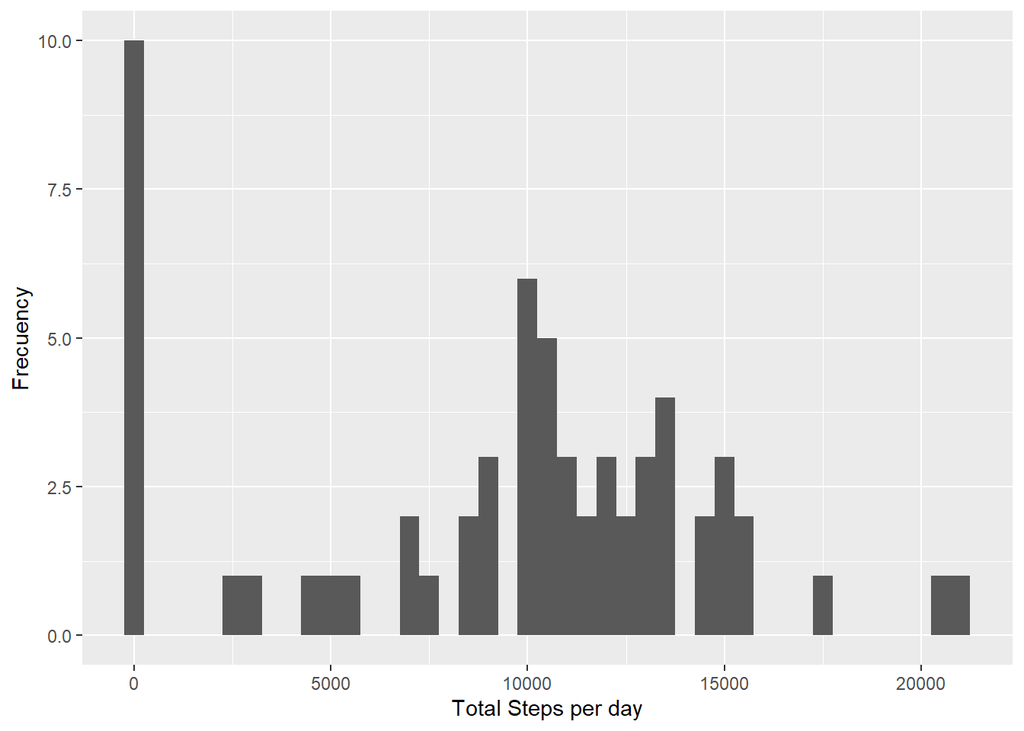

```r
library(ggplot2)
qplot(StepsPerDay,xlab = "Total Steps per day", ylab = "Frecuency",binwidth=500)
```

## What is the average daily activity pattern?

To calculate the Mean and the Median number step by day, I used the following code with their results:

```r
MeanStepPerDay<-mean(StepsPerDay)
MeanStepPerDay
```

```
## [1] 9354.23
```

```r
MedianStepPerDay<-median(StepsPerDay)
MedianStepPerDay
```

```
## [1] 10395
```

For the Time series plot average number steps taken and the 5-minute interval that, on average, contains the maximun numer of step, resulting a graphics, I code the following:

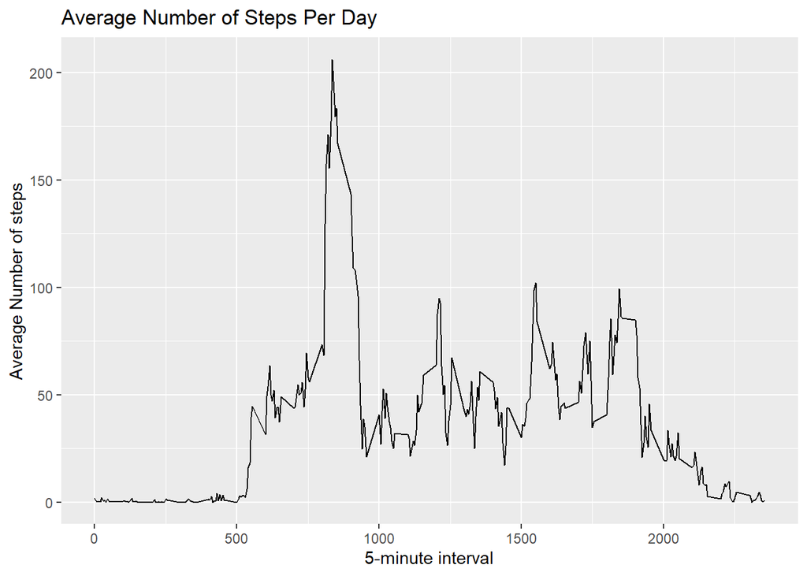

```r
AveDayActPatt<-aggregate(x=list(meanSteps=data$steps),by=list(interval=data$interval),       FUN=mean,na.rm=TRUE)

ggplot(data = AveDayActPatt,aes(x=interval,y=meanSteps))+geom_line()+ggtitle("Average Number of Steps Per Day")+xlab("5-minute interval")+ylab("Average Number of steps")
```

## The 5-minutes interval on average per day in the data contains the maximun number of steps?

```r
MaxSteps<-which.max(AveDayActPatt$meanSteps)
MostOfSteps<-gsub("([0-9]{1,2})([0-9]{2})","\\1:\\2",AveDayActPatt[MaxSteps,"interval"])
MostOfSteps
```

```
## [1] "8:35"
```

This “Interval number” indicates that 8.35 AM is the time when the average person is most active

The total number of missings values are calculate bu the next code

```r
MissingValues<-length(which(is.na(data$steps)))
MissingValues
```

```
## [1] 2304
```

## Make an Histogram of the number of total steps taken by day

Following the histogram which show the total steps taken by day, in thi section I consider the advantage for the data.table function. Folowing the code and the histogram.

```r
activity<-data.table::fread(input="activity.csv")
TotalSteps<-activity[,c(lapply(.SD,sum)),.SDcols=c("steps"),by=.(date)]
TotalSteps[,.(MeanSteps=mean(steps),MedianSteps=median(steps))]
```

```
##    MeanSteps MedianSteps
## 1:        NA          NA
```

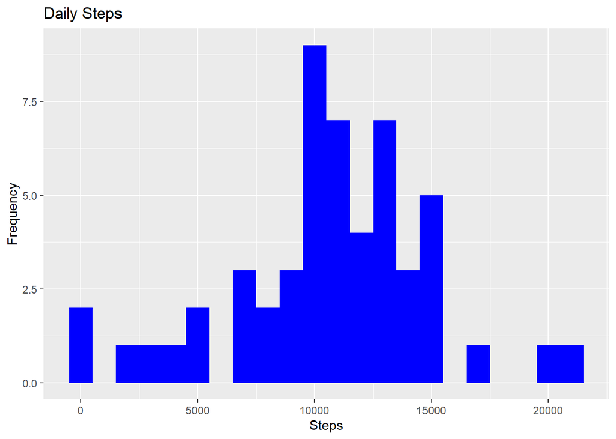

```r
ggplot(TotalSteps,aes(x=steps))+geom_histogram(fill="blue",binwidth = 1000)+labs(title="Daily Steps",x="Steps",y="Frequency")
```

## Are there differences in activity patterns between weekdays and weekends?

Building a factor variable considering weeks and weekends as follow:

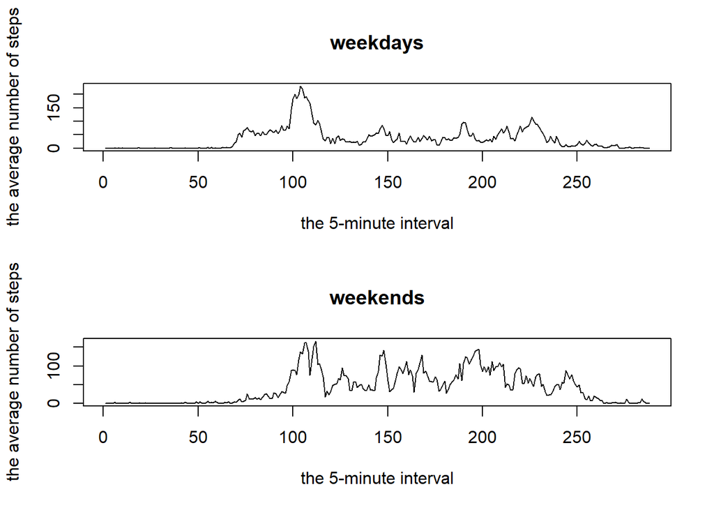

```r
data$date<-as.POSIXct(data$date)
dataFix <-data
for(i in unique(dataFix$interval)) {
    dataFix$steps[is.na(dataFix$steps) & dataFix$interval == i] <- round(mean(dataFix$steps[data$interval == i],na.rm = TRUE))
}
dataFix$weekDay<-as.POSIXlt(data$date)$wday == 0 | as.POSIXlt(data$date)$wday ==6
dataFix$weekDay<-factor(dataFix$weekDay,levels =c(F, T), labels=c("weekday","weekend"))

stepsWeekDay<-tapply(dataFix$steps[dataFix$weekDay=="weekday"],dataFix$interval[dataFix$weekDay=="weekday"],mean)
stepsWeekEnd<-tapply(dataFix$steps[dataFix$weekDay=="weekend"],dataFix$interval[dataFix$weekDay=="weekend"],mean)

par(mfrow = c(2,1))
plot(stepsWeekDay,type = "l",main = "weekdays"
     ,xlab = "the 5-minute interval"
     ,ylab = "the average number of steps")
plot(stepsWeekEnd,type = "l",main = "weekends"
     ,xlab = "the 5-minute interval"
     ,ylab = "the average number of steps")
```

## Loading and processing the data

The data had been delivered by Coursera assignment in the link (https://d396qusza40orc.cloudfront.net/repdata%2Fdata%2Factivity.zip), indicating that "NA’ values are missing values